# Exponential Smoothing Models of Uber

```r
source('uber_data_preprocessing.R')
```

```
Error in install.packages : Updating loaded packages
Error in install.packages : Updating loaded packages
```

```r
source('error_metrics.R')
```

In this notebook, I will explore exponential smoothing models. In particular, I will examine the following methods:

1 - Simple exponential smoothing

2 - Holt (with and without damping)

3 - ETS

The frequency of the series is too high for the Holt Winters model. Attemp to develop holt winters model will lead to get an error. As a result, I will skip this model.

```r
# defining the forecast horizon
h = length(uber_test)

# simple exponential model
ses_model <- ses(uber_train, h=h)

# holt's model
holt_model <- holt(uber_train, h=h)
damped_holt_model <- holt(uber_train, damped = T, h=h)

# ETS model
ets_model <- ets(uber_train)
```

Lets take a look at the ets model before we go on.

```r
ets_model %>% summary()
```

```
ETS(M,A,N)

Call:
 ets(y = uber_train)

  Smoothing parameters:
    alpha = 0.5257
    beta  = 0.0021

  Initial states:
    l = 7.5961
    b = 0.5529

  sigma:  0.0883

     AIC     AICc      BIC
1807.366 1807.651 1824.266

Training set error measures:
                     ME    RMSE      MAE       MPE     MAPE      MASE       ACF1
Training set -0.4246013 4.53834 3.180544 -1.225086 6.233171 0.1556106 0.01642082
```

Basically, the ets model suggests a holt approach without damping. The ets parameteres are obtained by minimazing the AICc. While the Holt’s parameters are obtained by mizimizing the SSE. The beta values obtained for the ets, holt, and damped holt values are approximately zero; hence, it seems that the simple exponential smoothing approach might be enough.

Now lets take a look how the models fit the training data.

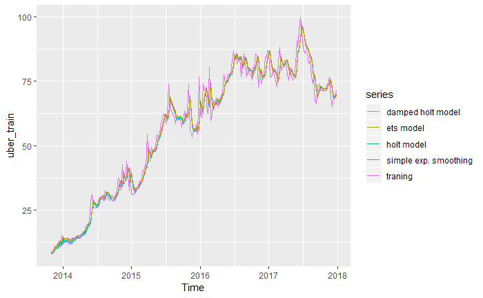

```r
autoplot(uber_train, series='traning') +
autolayer(fitted(ses_model), series='simple exp. smoothing') +
autolayer(fitted(holt_model), series='holt model') +
autolayer(fitted(damped_holt_model), series='damped holt model') +
autolayer(fitted(ets_model), series='ets model')
```

Visually, it seems that all model perform similar. As explained, the beta value is approximately zero, so this observation is not unexpected. Therefore, lets take a look at their performance quantitavely.

```r
accuracy(ses_model)
```

```
                    ME     RMSE      MAE      MPE     MAPE      MASE         ACF1
Training set 0.5157386 4.550841 3.217388 1.179359 6.346351 0.1574132 -0.006874365
```

```r
accuracy(holt_model)
```

```
                       ME     RMSE      MAE        MPE     MAPE     MASE      ACF1
Training set -0.003121848 4.520642 3.162587 -0.1193898 6.144954 0.154732 0.0142165
```

```r
accuracy(damped_holt_model)
```

```
                    ME     RMSE      MAE        MPE     MAPE      MASE      ACF1
Training set 0.1923761 4.516461 3.180515 -0.4541618 6.284735 0.1556092 0.0104894
```

```r
accuracy(ets_model)
```

```
                     ME    RMSE      MAE       MPE     MAPE      MASE       ACF1
Training set -0.4246013 4.53834 3.180544 -1.225086 6.233171 0.1556106 0.01642082
```

The error metrics for all models on the training set look very similar. In order to decide which model is better, I do the cross validation and calculate the RMSE value for all of the models.

```r
ses_error <- tsCV(uber_train, ses, h=1)
holt_error <-tsCV(uber_train, holt, h=1)
damped_holt_error <- tsCV(uber_train, holt, damped=T, h=1)
fets <- function(x,h){
    fit <- ets(x)
    return(forecast(fit, h=h))
}
ets_error <- tsCV(uber_train, fets, h=1)
```

```r
print(rmse(ses_error))
```

```
[1] 4.603745
```

```r
print(rmse(holt_error))
```

```
[1] 4.636184
```

```r
print(rmse(damped_holt_error))
```

```
[1] 4.626529
```

```r
print(rmse(ets_error))
```

```
[1] 4.696189
```

It seems that the simple exponential smoothing model slightly outperforms the others. Now, lets take a look at its residuals.

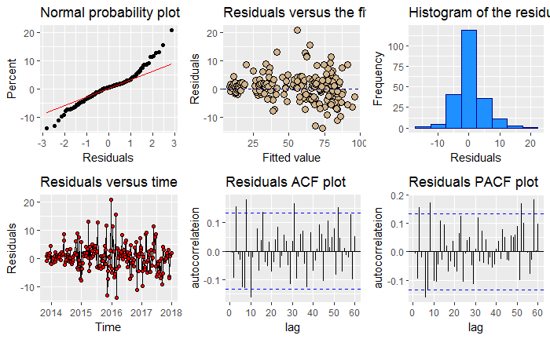

```r
residual_diognostics_plots(ses_model)
```

The residual plots show that the model does not satisfy the requirements entirely. In fact:

1 - The residuals do not follow a normal distribution, suggesting that the forecast’s confidence intervals may not be accurate.

2 - The residuals vs fitted value show some structure.

3 - The variation of the residuals changes a bit over the time.

4 - The are some time depencedy left unexplained in the data, based on the ACF and PACF plots. However, compared to naive model and piecewise linear model witn harmonics, which were exp,lored previously, the simple exponential smoothing model explains the time structure of the data better.

I am going to show the forecast for this model for the year 2018 and evaluate how the model performs. The forecast values will be constant.

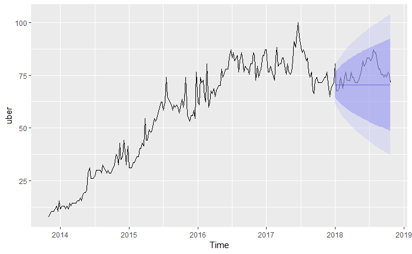

```r
ses_model_fcst <- forecast(ses_model, h=h)
autoplot(uber) +
autolayer(ses_model, alpha=0.4)
```

```r
accuracy(ses_model_fcst, uber)
```

```
                    ME     RMSE      MAE      MPE     MAPE      MASE         ACF1 Theil's U
Training set 0.5157386 4.550841 3.217388 1.179359 6.346351 0.1574132 -0.006874365        NA
Test set     5.7744416 7.648489 6.207715 7.174822 7.812034 0.3037173  0.784121247  2.269824
```

As seen in the table above, the error metrics for the testing set are worse than the training set. I believe the ses model is not the most appropriate model for this dataset. Hence, I will explore other models. Next, I will examine Arima models (with seasonality). Stay tuned.